# CIND820 Physical Health and Mental Health

Erica Tsui 501073613

Install packages for pre-processing and classification models.

```r
#install.packages("tidyverse")
#install.packages("haven")
#install.packages("rpart")
#install.packages("rpart.plot")
#install.packages("rattle")
#install.packages("caret")
#install.packages("corrplot")
#install.packages("ROSE")
#install.packages("naivebayes")
#install.packages("randomForest")
#install.packages("MASS")
#install.packages("knitr")
library(MASS)
library(tidyverse)
library(haven)
library(rpart)
library(rpart.plot)
library(rattle)
library(caret)
library(corrplot)
library(ROSE)
library(naivebayes)
library(randomForest)
library(knitr)
```

Import the BRFSS (Behavioral Risk Factor Surveillance System) 2019 dataset. The original file was in a SAS .xpt format but will be saved as a .csv after processing.  
The file is in a zip file located at https://www.cdc.gov/brfss/annual_data/2019/files/LLCP2019XPT.zip

```r
LLCP_2019 <- read_xpt(file = "D:/School/CIND820/LLCP2019.xpt")
```

Extract the desired variables and rename them with more intuitive labels and to make them more readable by R.

```r
BRFSS_raw <- LLCP_2019 %>%
  dplyr::select(
    MENTHLTH, `_AGE80`, `_RACE`, `_SEX`, `_BMI5`, `CHILDREN`,
    `_EDUCAG`, `INCOME2`, TRNSGNDR, SOMALE, SOFEMALE, MARITAL,
    EMPLOY1, GENHLTH, PHYSHLTH, `_SMOKER3`, `_DRNKWK1`, `_FRUTSU1`, `_VEGESU1`,
    `_PA150R3`, `_RFHYPE5`, `_RFCHOL2`, `_ASTHMS1`, `_DRDXAR2`
    ) %>%
  rename(
    mental_health = MENTHLTH,
    age = `_AGE80`,
    race = `_RACE`,
    sex = `_SEX`,
    bmi = `_BMI5`,
    children = `CHILDREN`,
    education = `_EDUCAG`,
    income = `INCOME2`,
    transgender = TRNSGNDR,
    sexorient_male = SOMALE,
    sexorient_fem = SOFEMALE,
    marital = MARITAL,
    employment = EMPLOY1,
    gen_health = `GENHLTH`,
    bad_health_days = `PHYSHLTH`,
    smoker = `_SMOKER3`,
    drinks_week = `_DRNKWK1`,
    fruit_day = `_FRUTSU1`,
    vegetable_day = `_VEGESU1`,
    exercise_150 = `_PA150R3`,
    blood_pres = `_RFHYPE5`,
    cholesterol = `_RFCHOL2`,
    asthma = `_ASTHMS1`,
    arthritis = `_DRDXAR2`
  )
```

For each variable the responses were tallied to identify NA, “refused” or “don’t know” responses. The “don’t know/refused” responses were coded 7/77 or 9/99/99900 depending on the variable. Any rows having these three response types were removed before further data exploration. There was some inconsistency with how valid zero responses were recorded. Variables that coded 0 as ‘88’ were corrected to avoid R treating the response as a numerical 88.

```r
summary(BRFSS_raw)
```

```
##  mental_health        age             race            sex
##  Min.   : 1.00   Min.   :18.00   Min.   :1.000   Min.   :1.000
##  1st Qu.:15.00   1st Qu.:42.00   1st Qu.:1.000   1st Qu.:1.000
##  Median :88.00   Median :58.00   Median :1.000   Median :2.000
##  Mean   :61.75   Mean   :55.38   Mean   :2.151   Mean   :1.546
##  3rd Qu.:88.00   3rd Qu.:70.00   3rd Qu.:2.000   3rd Qu.:2.000
##  Max.   :99.00   Max.   :80.00   Max.   :9.000   Max.   :2.000
##  NA's   :19                      NA's   :3
##       bmi           children       education         income
##  Min.   :1200    Min.   : 1.00   Min.   :1.000   Min.   : 1.00
##  1st Qu.:2402    1st Qu.: 5.00   1st Qu.:2.000   1st Qu.: 5.00
##  Median :2734    Median :88.00   Median :3.000   Median : 7.00
##  Mean   :2833    Mean   :66.15   Mean   :2.993   Mean   :20.69
##  3rd Qu.:3145    3rd Qu.:88.00   3rd Qu.:4.000   3rd Qu.: 8.00
##  Max.   :9984    Max.   :99.00   Max.   :9.000   Max.   :99.00
##  NA's   :36203   NA's   :4741                    NA's   :6881
##   transgender     sexorient_male   sexorient_fem       marital
##  Min.   :1.00     Min.   :1.00     Min.   :1.00     Min.   :1.00
##  1st Qu.:4.00     1st Qu.:2.00     1st Qu.:2.00     1st Qu.:1.00
##  Median :4.00     Median :2.00     Median :2.00     Median :1.00
##  Mean   :4.04     Mean   :2.18     Mean   :2.26     Mean   :2.36
##  3rd Qu.:4.00     3rd Qu.:2.00     3rd Qu.:2.00     3rd Qu.:3.00
##  Max.   :9.00     Max.   :9.00     Max.   :9.00     Max.   :9.00
##  NA's   :184177   NA's   :311953   NA's   :289933   NA's   :49
##    employment      gen_health   bad_health_days     smoker       drinks_week
##  Min.   :1.000   Min.   :1.00   Min.   : 1.00   Min.   :1.000   Min.   :    0
##  1st Qu.:1.000   1st Qu.:2.00   1st Qu.:15.00   1st Qu.:3.000   1st Qu.:    0
##  Median :3.000   Median :3.00   Median :88.00   Median :4.000   Median :   23
##  Mean   :3.951   Mean   :2.62   Mean   :59.51   Mean   :3.593   Mean   : 6892
##  3rd Qu.:7.000   3rd Qu.:3.00   3rd Qu.:88.00   3rd Qu.:4.000   3rd Qu.:  400
##  Max.   :9.000   Max.   :9.00   Max.   :99.00   Max.   :9.000   Max.   :99900
##  NA's   :2859    NA's   :26     NA's   :32
##    fruit_day       vegetable_day      exercise_150    blood_pres
##  Min.   :    0.0   Min.   :    0.0   Min.   :1.00   Min.   :1.000
##  1st Qu.:   56.0   1st Qu.:  114.0   1st Qu.:1.00   1st Qu.:1.000
##  Median :  100.0   Median :  165.0   Median :2.00   Median :1.000
##  Mean   :  144.8   Mean   :  204.1   Mean   :2.64   Mean   :1.436
##  3rd Qu.:  200.0   3rd Qu.:  229.0   3rd Qu.:3.00   3rd Qu.:2.000
##  Max.   :17600.0   Max.   :13204.0   Max.   :9.00   Max.   :9.000
##  NA's   :44600     NA's   :53430
##   cholesterol        asthma        arthritis
##  Min.   :1.00    Min.   :1.000   Min.   :1.000
##  1st Qu.:1.00    1st Qu.:3.000   1st Qu.:1.000
##  Median :1.00    Median :3.000   Median :2.000
##  Mean   :1.46    Mean   :2.817   Mean   :1.664
##  3rd Qu.:2.00    3rd Qu.:3.000   3rd Qu.:2.000
##  Max.   :9.00    Max.   :9.000   Max.   :2.000
##  NA's   :48535                   NA's   :2545
```

```r
#Repeat below for every variable
c <- count(BRFSS_raw, mental_health)
view(c)
```

Every variable was cleaned for the three responses mentioned above. Most of the original variables were coded numerically instead of the named categories and when the dataset was imported all the classes were defaulted to numerical. Variables had their numerical codes replaced with the actual names and set to the correct ordinal or nominal classes if appropriate. Outliers were defined as being more than 3 standard deviations away from the mean (after cleaning and adjusting ‘88’ responses) and removed. Most outliers only fell on the right boundary since the left would have been in the negatives and impossible (ex. negative fruit consumption). Some variable categories were combined. The transgender and sexual orientation variables were removed completely due to the high number of NA results.

```r
#Change mental health days from numerical to Yes/No
BRFSS <- BRFSS_raw %>%
  filter(!(is.na(mental_health) | mental_health %in% c(77,99))) %>%
  mutate(mental_health = factor(ifelse(mental_health == 88, "No", "Yes"),
                                ordered = FALSE))

#Change race values to unordered names
#Combine Hawaiians (5) into Other (6)
BRFSS <- BRFSS %>%
  filter(!(is.na(race) | race == 9)) %>%
  mutate(race = factor(case_when(race == 1 ~ "White",
                                 race == 2 ~ "Black",
                                 race == 3 ~ "Indigenous",
                                 race == 4 ~ "Asian",
                                 race %in% c(5, 6) ~ "Other",
                                 race == 7 ~ "Multiracial",
                                 race == 8 ~ "Hispanic"),
                       ordered = FALSE))

#Re-label sex to male and female
BRFSS <- BRFSS %>%
  mutate(sex = factor(ifelse(sex == 1, "Male", "Female"), ordered = FALSE))

#Calculating BMI outliers then removing
bmi_sd <- sd(BRFSS$bmi, na.rm = TRUE)
bmi_mean <- mean(BRFSS$bmi, na.rm = TRUE)
bmi_out_lower <- bmi_mean - (3 * bmi_sd)
bmi_out_upper <- bmi_mean + (3 * bmi_sd)

BRFSS <- BRFSS %>%
  filter(!(is.na(bmi)) & (bmi > bmi_out_lower) & (bmi < bmi_out_upper))

#Re-label children entry '88' to 0 children
BRFSS <- BRFSS %>%
  filter(!(is.na(children) | children == 99)) %>%
  mutate(children = replace(children, children == 88, 0))

#Calculating outliers, rounded up for whole children
child_sd <- sd(BRFSS$children)
child_mean <- mean(BRFSS$children)
child_out_upper <- round(child_mean + (3 * child_sd))

#Removing right side children outliers, no left needed since no negative kids
BRFSS <- BRFSS[BRFSS$children <= child_out_upper,]

#Set education to ordinal levels and names
BRFSS <- BRFSS %>%
  filter(!(is.na(education) | education == 9)) %>%
  mutate(education = factor(case_when(education == 1 ~ "Some High School",
                                      education == 2 ~ "High School",
                                      education == 3 ~ "Some Post Secondary",
                                      education == 4 ~ "Post Secondary"),
                            levels = c("Some High School", "High School",
                                       "Some Post Secondary", "Post Secondary"),
                            ordered = TRUE))

#Set income to ordinal level bins
BRFSS <- BRFSS %>%
  filter(!(is.na(income) | income %in% c(77,99))) %>%
  mutate(income = factor(case_when(income == 1 ~ "<10",
                                   income == 2 ~ "10-15",
                                   income == 3 ~ "15-20",
                                   income == 4 ~ "20-25",
                                   income == 5 ~ "25-35",
                                   income == 6 ~ "35-50",
                                   income == 7 ~ "50-75",
                                   income == 8 ~ ">75"),
                         levels = c("<10", "10-15", "15-20", "20-25",
                                    "25-35", "35-50", "50-75", ">75"),
                         ordered = TRUE))

#Remove transgender variable due to high NAs
paste("Transgender variable NA sum: ", sum(is.na(BRFSS$transgender)))
```

```
## [1] "Transgender variable NA sum:  131034"
```

```r
BRFSS$transgender <- NULL

#Combine sex orientation of males and females into a new column
BRFSS <- BRFSS %>%
  mutate(orientation = coalesce(sexorient_male, sexorient_fem))
#Checking how many NA values exist after combining genders into one column
paste("Sexual orientation variable NA sum: ", sum(is.na(BRFSS$orientation)))
```

```
## [1] "Sexual orientation variable NA sum:  130603"
```

```r
#Removing all sexual orientation columns due to high NAs
BRFSS$sexorient_male <- NULL
BRFSS$sexorient_fem <- NULL
BRFSS$orientation <- NULL

#Re-label marital status to nominal titles
BRFSS <- BRFSS %>%
  filter(!(is.na(marital) | marital == 9)) %>%
  mutate(marital = factor(case_when(marital == 1 ~ "Married",
                                    marital == 2 ~ "Divorced",
                                    marital == 3 ~ "Widowed",
                                    marital == 4 ~ "Separated",
                                    marital == 5 ~ "Never Married",
                                    marital == 6 ~ "Unmarried Couple"),
                          ordered = FALSE))

#Re-label employment, merge "Employed for wages" with "Self-employed"
#Merge all unemployment categories into single "Unemployed"
BRFSS <- BRFSS %>%
  filter(!(is.na(employment) | employment == 9)) %>%
  mutate(employment = factor(case_when(employment %in% c(1, 2) ~ "Employed",
                                       employment %in% c(3:6) ~ "Unemployed",
                                       employment == 7 ~ "Retired",
                                       employment == 8 ~ "Unable to Work"),
                             ordered = FALSE))

#Re-label general health status and set ordinal levels
BRFSS <- BRFSS %>%
  filter(!(is.na(gen_health) | gen_health %in% c(7,9))) %>%
  mutate(gen_health = factor(case_when(gen_health == 1 ~ "Excellent",
                                       gen_health == 2 ~ "Very Good",
                                       gen_health == 3 ~ "Good",
                                       gen_health == 4 ~ "Fair",
                                       gen_health == 5 ~ "Poor"),
                             levels = c("Poor", "Fair", "Good", "Very Good",
                                        "Excellent"),
                             ordered = TRUE))

#Set bad_health_days response '88' to 0 days
BRFSS <- BRFSS %>%
  filter(!(is.na(bad_health_days) | bad_health_days %in% c(77,99))) %>%
  mutate(bad_health_days = replace(bad_health_days, bad_health_days == 88, 0))

#Re-label smoking status
BRFSS <- BRFSS %>%
  filter(!(is.na(smoker) | smoker == 9)) %>%
  mutate(smoker = factor(case_when(smoker %in% c(1, 2) ~ "Current Smoker",
                                   smoker == 3 ~ "Former Smoker",
                                   smoker == 4 ~ "Never Smoked"),
                         ordered = FALSE))

#Remove drinks per week outliers (calculated after removing '99900' responses)
BRFSS <- BRFSS[BRFSS$drinks_week != 99900,]

drink_sd <- sd(BRFSS$drinks_week)
drink_mean <- mean(BRFSS$drinks_week)
drink_out_upper <- drink_mean + (3 * drink_sd) #No lower bound needed
BRFSS <- BRFSS[BRFSS$drinks_week <= drink_out_upper,]

#Remove fruits per day and vegetables per day outliers
fruit_sd <- sd(BRFSS$fruit_day, na.rm = TRUE)
fruit_mean <- mean(BRFSS$fruit_day, na.rm = TRUE)
fruit_out_upper <- fruit_mean + (3 * fruit_sd) #No lower bound needed

veg_sd <- sd(BRFSS$vegetable_day, na.rm = TRUE)
veg_mean <- mean(BRFSS$vegetable_day, na.rm = TRUE)
veg_out_upper <- veg_mean + (3 * veg_sd) #No lower bound needed

BRFSS <- BRFSS %>%
  filter(!(is.na(fruit_day) | fruit_day > fruit_out_upper)) %>%
  filter(!(is.na(vegetable_day) | vegetable_day > veg_out_upper))

#Re-label exercise time ranges and set ordinal factor levels
BRFSS <- BRFSS %>%
  filter(!(is.na(exercise_150) | exercise_150 == 9)) %>%
  mutate(exercise_150 = factor(case_when(exercise_150 == 1 ~ ">150",
                                         exercise_150 == 2 ~ "1-149",
                                         exercise_150 == 3 ~ "0",),
                               levels = c("0", "1-149", ">150"),
                               ordered = TRUE))

#Re-label high blood pressure to Yes and No
BRFSS <- BRFSS %>%
  filter(!(is.na(blood_pres) | blood_pres == 9)) %>%
  mutate(blood_pres = factor(ifelse(blood_pres == 1, "No", "Yes"),
                             ordered = FALSE))

#Re-label high cholesterol to Yes and No
BRFSS <- BRFSS %>%
  filter(!(is.na(cholesterol) | cholesterol == 9)) %>%
  mutate(cholesterol = factor(ifelse(cholesterol == 1, "No", "Yes"),
                              ordered = FALSE))

#Re-label asthma status
BRFSS <- BRFSS %>%
  filter(!(is.na(asthma) | asthma == 9)) %>%
  mutate(asthma = factor(case_when(asthma == 1 ~ "Current",
                                   asthma == 2 ~ "Former",
                                   asthma == 3 ~ "Never"),
                         ordered = FALSE))

#Re-label arthritis to Yes and No
BRFSS <- BRFSS %>%
  filter(!(is.na(arthritis))) %>%
  mutate(arthritis = factor(ifelse(arthritis == 1, "Yes", "No"),
                            ordered = FALSE))

write.csv(BRFSS, "BRFSS.csv")
```

Race and BMI supported the dataset reflecting the US population. The large number of White respondents was close to the US Census reported 76%. The CDC says a normal BMI is 18 - 25 which was close to the peak of the BMI distribution.

Most respondents rated their general physical health as good or very good but not the highest rating of excellent. Since it was a self-rating there was the possibility that a mentally unwell person may perceive their physical health differently than a mentally healthy person. A related numerical variable was the number of bad physical health days in the last 30 days. More than half of the respondents said they experienced 0 bad days. Interestingly, the distribution of those who experienced some bad days dipped in the middle. It seemed people either experienced very short term problems or had chronic conditions but few reported moderate length problems.

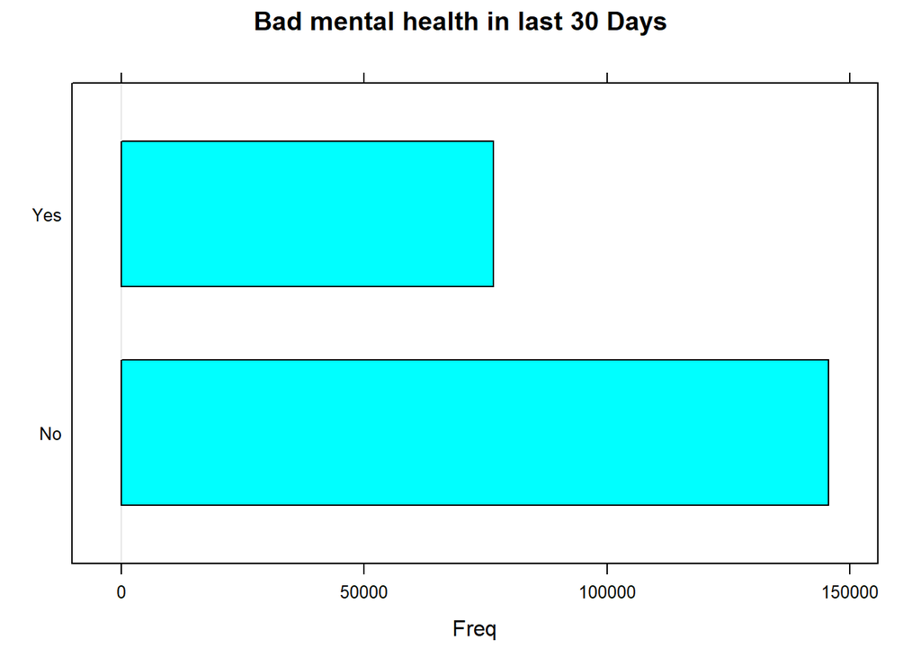

```r
barchart(BRFSS$mental_health, main = "Bad mental health in last 30 Days")
```

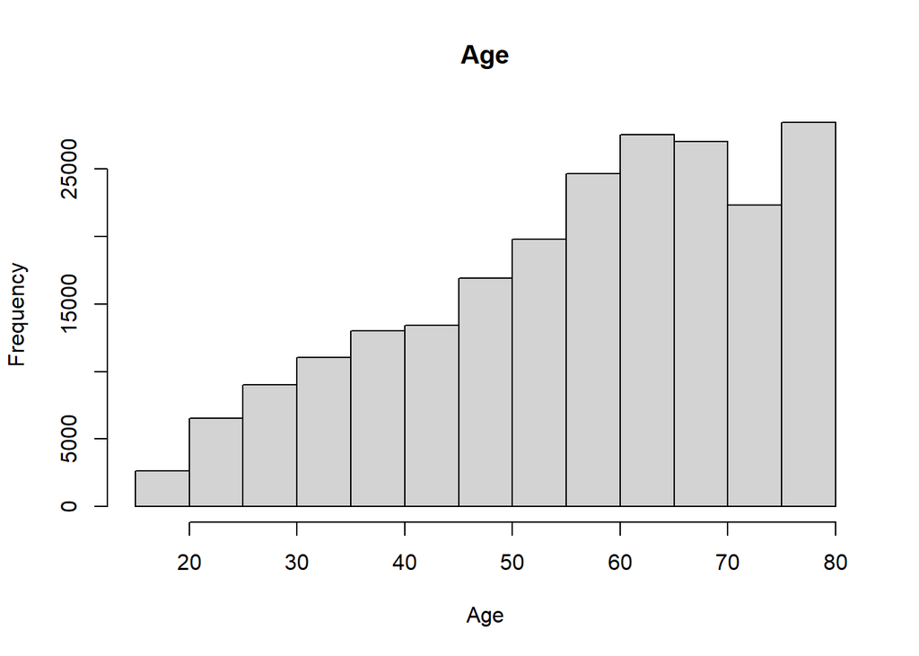

```r
hist(BRFSS$age, main = 'Age', xlab = 'Age')
```

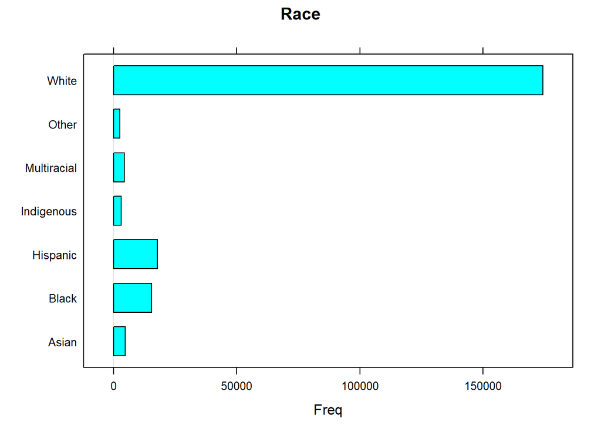

```r
barchart(BRFSS$race, main = "Race")
```

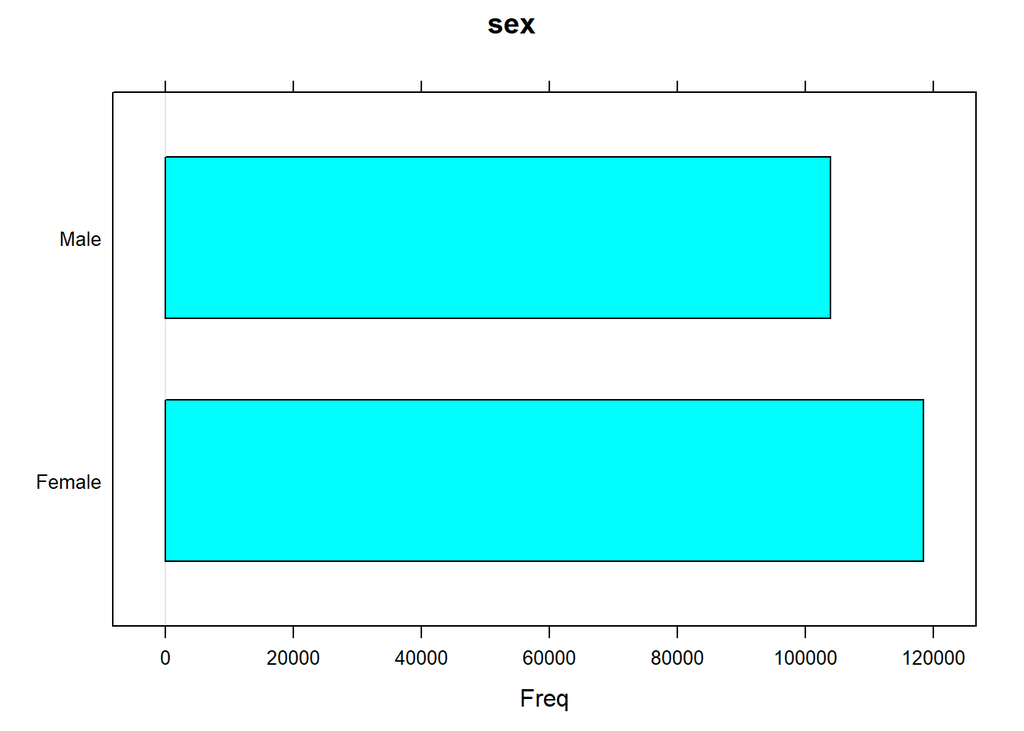

```r
barchart(BRFSS$sex, main = "sex")
```

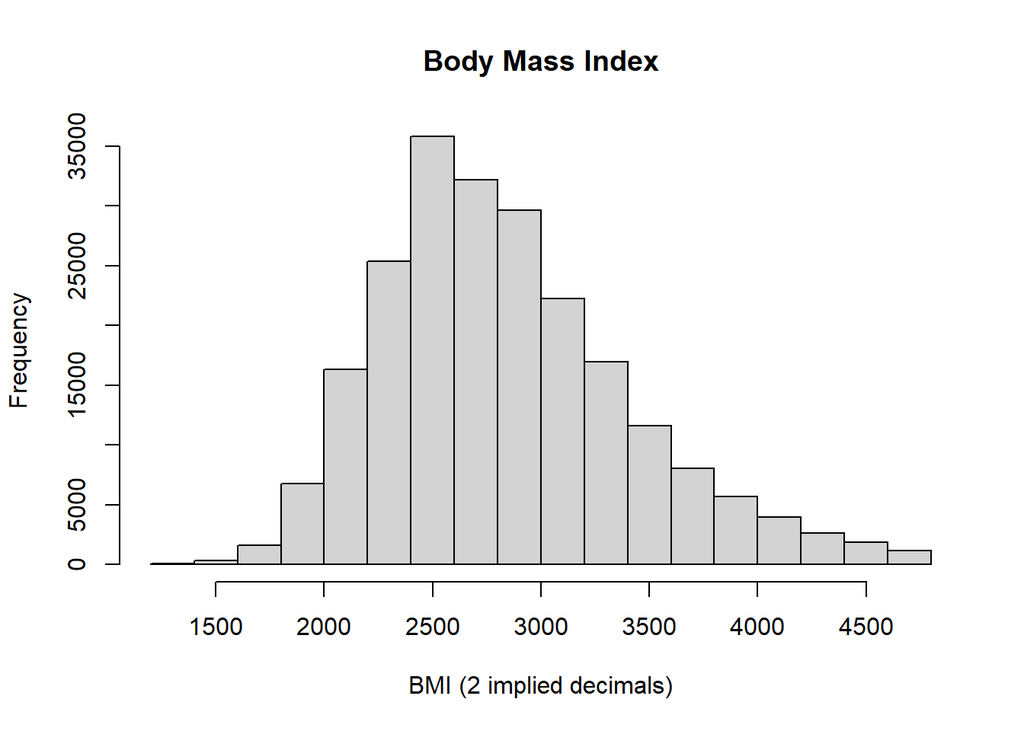

```r
hist(BRFSS$bmi, main = "Body Mass Index", xlab = "BMI (2 implied decimals)")
```

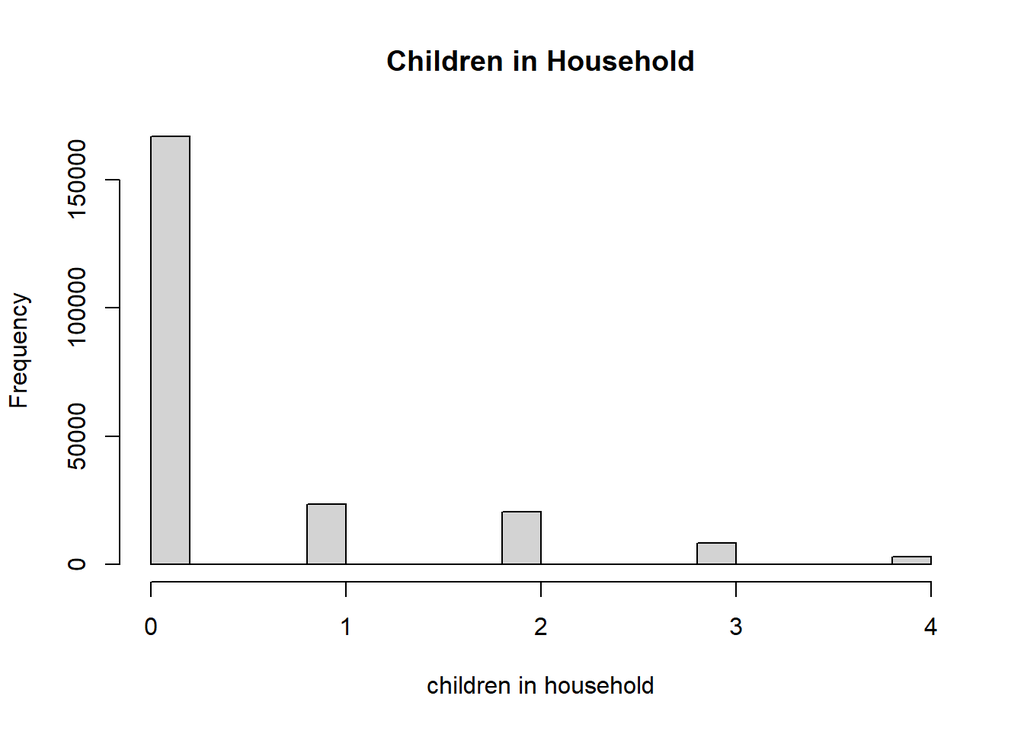

```r
hist(BRFSS$children, main = "Children in Household",
     xlab="children in household")
```

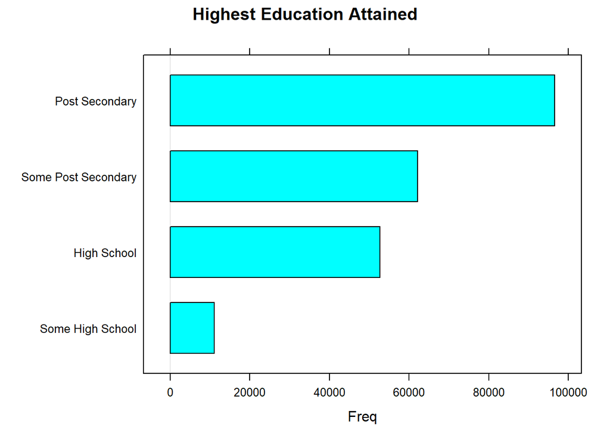

```r
barchart(BRFSS$education, main = "Highest Education Attained")
```

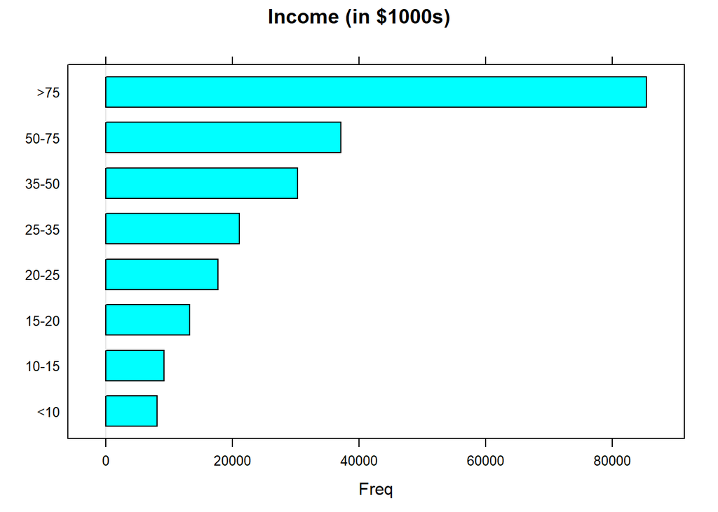

```r
barchart(BRFSS$income, main = "Income (in $1000s)")
```

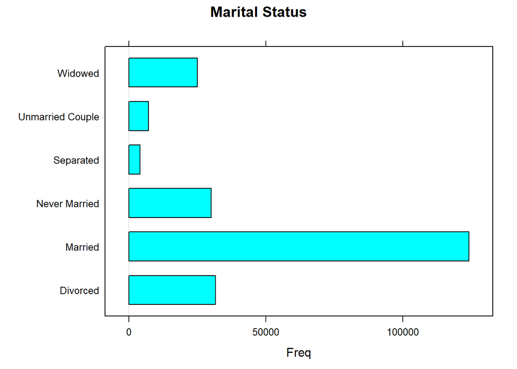

```r
barchart(BRFSS$marital, main = "Marital Status")
```

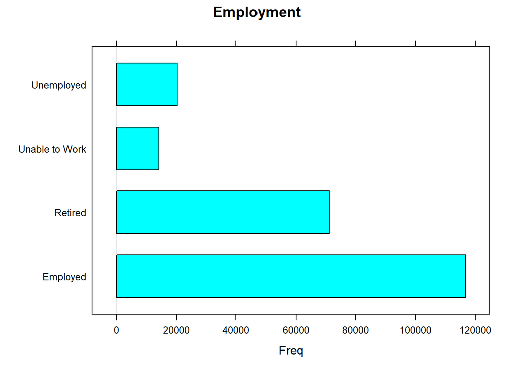

```r
barchart(BRFSS$employment, main = "Employment")
```

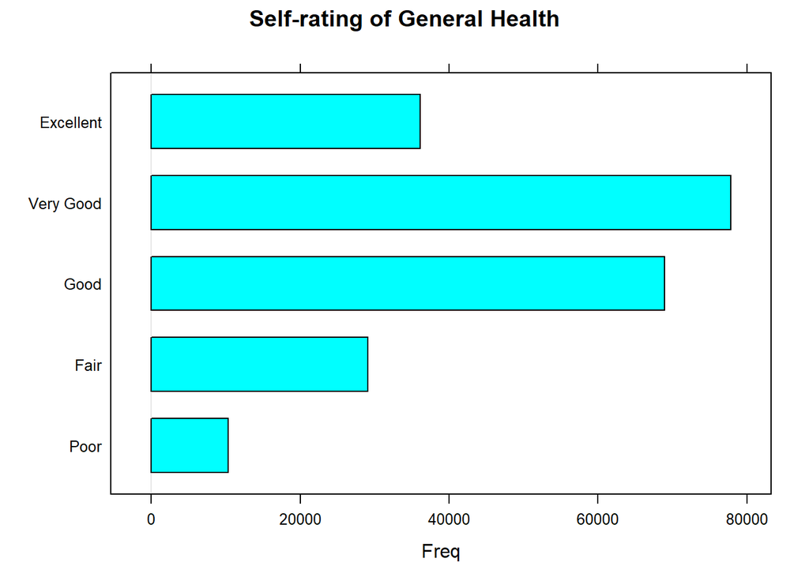

```r
barchart(BRFSS$gen_health, main = "Self-rating of General Health")
```

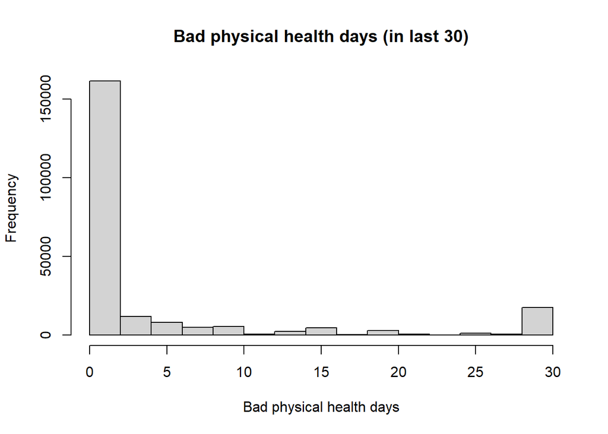

```r
hist(BRFSS$bad_health_days, main = "Bad physical health days (in last 30)",
     xlab = "Bad physical health days")
```

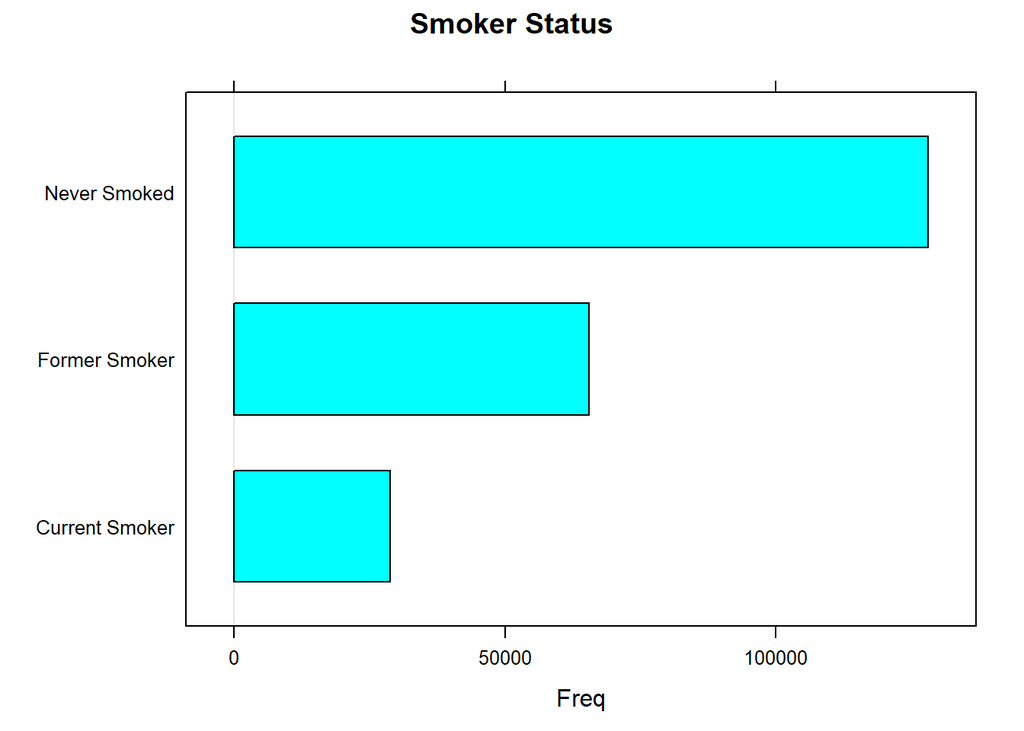

```r
barchart(BRFSS$smoker, main = "Smoker Status")
```

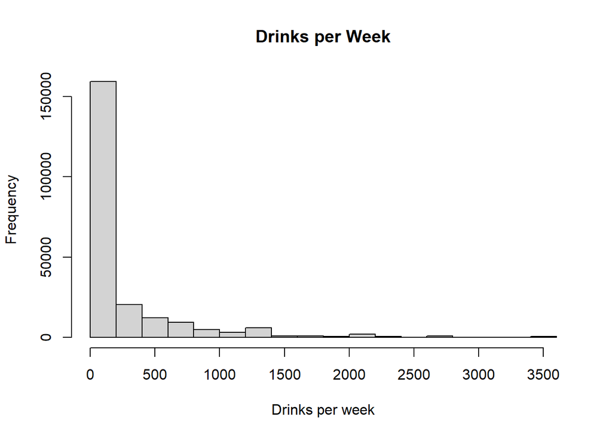

```r
hist(BRFSS$drinks_week, main = "Drinks per Week", xlab = "Drinks per week")
```

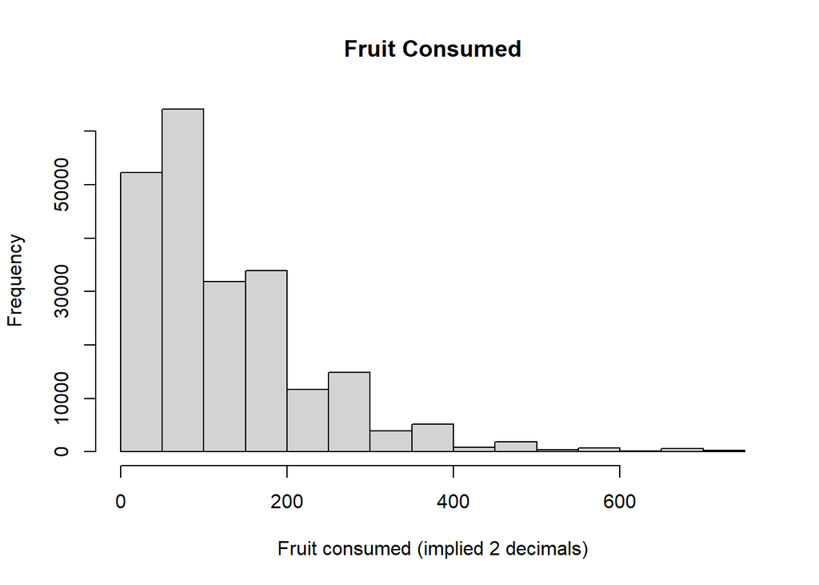

```r
hist(BRFSS$fruit_day, main = "Fruit Consumed",
     xlab = "Fruit consumed (implied 2 decimals)")
```

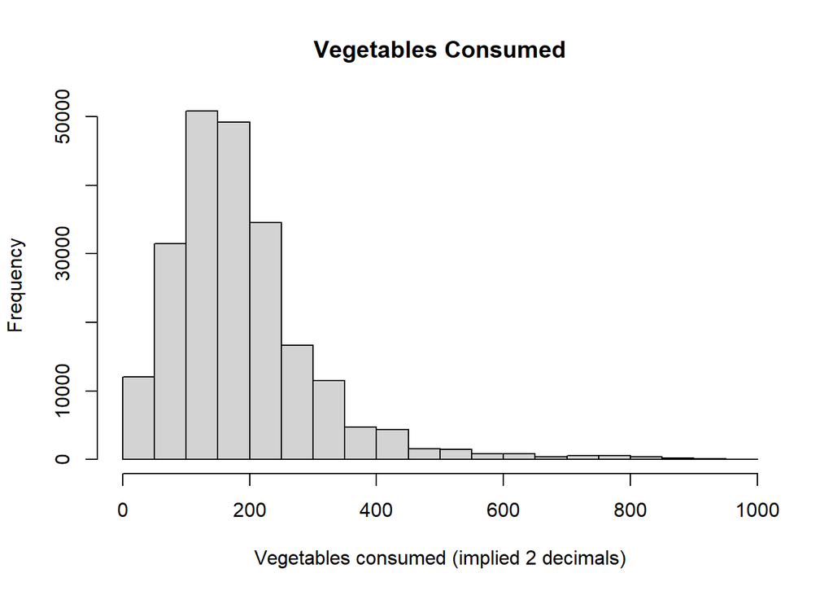

```r
hist(BRFSS$vegetable_day, main = "Vegetables Consumed",
     xlab = "Vegetables consumed (implied 2 decimals)")
```

The below correlation matrix and visualization shows the correlation for most the independent variables were not very high. The two exceptions being:  
1) The moderate negative correlation between the respondent’s age and children in the household. As age increased the number of children in the household decreased.  
2) The weak positive correlation between fruit and vegetables consumed. It was expected that drinks per week would have a moderate negative correlation with fruits and vegetables but the matrix showed little relationship.  
Unfortunately some categorical variables did not have numerical data and could not be included in the correlation matrix. The income variable in particular would have been good to include but only had range responses instead of numerical.

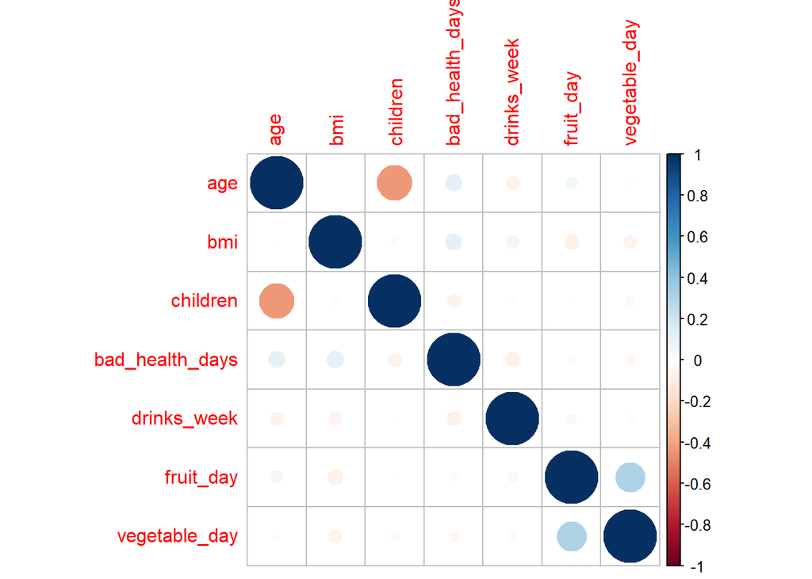

```r
BRFSS_num <- BRFSS %>%
  dplyr::select(age, bmi, children, bad_health_days, drinks_week, fruit_day,
                vegetable_day)

BRFSS_num_corr <- cor(BRFSS_num)
corrplot(BRFSS_num_corr, method = "circle")
```

```r
BRFSS_num_corr
```

```
##                          age          bmi     children bad_health_days
## age              1.000000000 -0.007476412 -0.438247213      0.10518965
## bmi             -0.007476412  1.000000000  0.023730293      0.10172761
## children        -0.438247213  0.023730293  1.000000000     -0.06912092
## bad_health_days  0.105189649  0.101727611 -0.069120921      1.00000000
## drinks_week     -0.067162533 -0.064112980 -0.014949621     -0.07241124
## fruit_day        0.053420931 -0.079160738  0.009238615     -0.02924298
## vegetable_day   -0.015441256 -0.062045495  0.030951869     -0.04634879
##                 drinks_week    fruit_day vegetable_day
## age             -0.06716253  0.053420931   -0.01544126
## bmi             -0.06411298 -0.079160738   -0.06204550
## children        -0.01494962  0.009238615    0.03095187
## bad_health_days -0.07241124 -0.029242976   -0.04634879
## drinks_week      1.00000000 -0.037424573    0.02626387
## fruit_day       -0.03742457  1.000000000    0.30642453
## vegetable_day    0.02626387  0.306424527    1.00000000
```

The classification models used are:  
1) Decision Tree  
2) Random Forest  
3) Naive Bayes  
4) Logistic Regression  
To prepare, the dataset was split into a train and test group. The ratio was 70:30 train to test.

```r
set.seed(10)
test_index <- sample(1:nrow(BRFSS), nrow(BRFSS) * 0.3)
train_set <- as.data.frame(BRFSS[-test_index, ])
test_set <- as.data.frame(BRFSS[test_index, ])
```

The dependent mental_health variable is imbalanced with 65% ‘No’ and 35% ‘Yes’. This was balanced using ROSE (Random Over-Sampling Examples) to generate more ‘Yes’ responses. This was only done on the training set since artificially created records in the test set would negatively affect the results. Unfortunately, The ROSE function only accepts numeric and unordered factors so the ordering was removed from the applicable variables.

```r
#Remove factor ordering for balanced set
train_set_bal <- train_set
train_set_bal$education <- factor(train_set_bal$education, ordered = FALSE)
train_set_bal$income <- factor(train_set_bal$income, ordered = FALSE)
train_set_bal$gen_health <- factor(train_set_bal$gen_health, ordered = FALSE)
train_set_bal$exercise_150 <- factor(train_set_bal$exercise_150, ordered = FALSE)

#Balancing with ROSE and checking ratio
kable(prop.table(table(train_set$mental_health)), "simple",
      caption = "Mental health response variable before balancing",
      col.names = c(" ", "Frequency")) #65% No to 35% Yes
```

Mental health response variable before balancing

|  | Frequency |
| --- | --- |
| No | 0.6537703 |
| Yes | 0.3462297 |

```r
#Calc min size needed to balance
total_size_need <- table(train_set_bal$mental_health)[[1]] * 2
train_set_bal <- ROSE(mental_health ~., data = train_set_bal,
                    N = total_size_need, p = 0.5)$data

#Confirming balance
kable(prop.table(table(train_set_bal$mental_health)), "simple",
      caption = "Mental health response variable after balancing",
      col.names = c(" ", "Frequency")) #50% No to 50% Yes
```

Mental health response variable after balancing

|  | Frequency |
| --- | --- |
| No | 0.4972868 |
| Yes | 0.5027132 |

K-fold validation was used for Decision Tree, Naive Bayes, and Logistic Regression but not Random Forest. It was left at the default 10 folds. Since the models all used the same test set to predict and compare results, k-fold was only applied to the training set after balancing. It would have been too computationally expensive to balance each training fold as it was used.

```r
set.seed(10)
k_fold_train <- trainControl(method = "cv", number = 10)
```

Decision Tree Classifier - Default  
For the first run the function was left completely default with all the variables. The resulting tree only split twice and the terminal nodes had a high impurity. Specificity was inflated because the model was rejecting more cases as no risk. The biggest issue was the low recall even though precision was also low (confirmed by the low F1 score). These combined measurements showed that this model was missing at risk people.

```r
train_tree_default <- rpart(mental_health ~ ., data = train_set, method = "class")
summary(train_tree_default)
```

```
## Call:
## rpart(formula = mental_health ~ ., data = train_set, method = "class")
##   n= 155599
##
##           CP nsplit rel error    xerror        xstd
## 1 0.05954745      0 1.0000000 1.0000000 0.003483590
## 2 0.01000000      2 0.8809051 0.8828356 0.003373178
##
## Variable importance
## bad_health_days             age      employment      gen_health       arthritis
##              46              12              12              12               5
##        children      blood_pres         marital          asthma          income
##               3               3               2               2               2
##
## Node number 1: 155599 observations,    complexity param=0.05954745
##   predicted class=No   expected loss=0.3462297  P(node) =1
##     class counts: 101726 53873
##    probabilities: 0.654 0.346
##   left son=2 (96189 obs) right son=3 (59410 obs)
##   Primary splits:
##       bad_health_days < 0.5  to the left,  improve=4796.958, (0 missing)
##       age             < 57.5 to the right, improve=2615.818, (0 missing)
##       gen_health      splits as  RRLLL,    improve=2068.560, (0 missing)
##       employment      splits as  LLRR,     improve=1965.552, (0 missing)
##       marital         splits as  RLRRRL,   improve=1469.171, (0 missing)
##   Surrogate splits:
##       gen_health splits as  RRLLL,    agree=0.718, adj=0.261, (0 split)
##       employment splits as  LLRL,     agree=0.657, adj=0.102, (0 split)
##       arthritis  splits as  LR,       agree=0.637, adj=0.050, (0 split)
##       asthma     splits as  RLL,      agree=0.634, adj=0.042, (0 split)
##       income     splits as  RRRLLLLL, agree=0.634, adj=0.041, (0 split)
##
## Node number 2: 96189 observations
##   predicted class=No   expected loss=0.2486563  P(node) =0.6181852
##     class counts: 72271 23918
##    probabilities: 0.751 0.249
##
## Node number 3: 59410 observations,    complexity param=0.05954745
##   predicted class=Yes  expected loss=0.495792  P(node) =0.3818148
##     class counts: 29455 29955
```

[output cut: 9 more lines]

```
##       employment splits as  RLRR,     agree=0.823, adj=0.613, (0 split)
##       children   < 0.5  to the left,  agree=0.648, adj=0.231, (0 split)
##       blood_pres splits as  RL,       agree=0.640, adj=0.214, (0 split)
##       arthritis  splits as  RL,       agree=0.636, adj=0.205, (0 split)
##       marital    splits as  RRRRRL,   agree=0.632, adj=0.197, (0 split)
##
## Node number 6: 27206 observations
##   predicted class=No   expected loss=0.391274  P(node) =0.1748469
##     class counts: 16561 10645
##    probabilities: 0.609 0.391
##
## Node number 7: 32204 observations
##   predicted class=Yes  expected loss=0.400385  P(node) =0.2069679
##     class counts: 12894 19310
##    probabilities: 0.400 0.600
```

[figure not shown]

```r
fancyRpartPlot(train_tree_default)
```

```r
test_tree_pred <- predict(train_tree_default, newdata = test_set, type = "class")
tree_table_default <- table(Predicted = factor(test_tree_pred, levels = c("Yes", "No")),
                            Actual = factor(test_set$mental_health, levels = c("Yes", "No")))
tree_cm_default <- confusionMatrix(tree_table_default, positive = "Yes")
tree_cm_default
```

```
## Confusion Matrix and Statistics
##
##          Actual
## Predicted   Yes    No
##       Yes  8211  5526
##       No  14580 38367
##
##                Accuracy : 0.6985
##                  95% CI : (0.695, 0.702)
##     No Information Rate : 0.6582
##     P-Value [Acc > NIR] : < 2.2e-16
##
##                   Kappa : 0.2591
##
##  Mcnemar's Test P-Value : < 2.2e-16
##
##             Sensitivity : 0.3603
##             Specificity : 0.8741
##          Pos Pred Value : 0.5977
##          Neg Pred Value : 0.7246
##              Prevalence : 0.3418
##          Detection Rate : 0.1231
##    Detection Prevalence : 0.2060
##       Balanced Accuracy : 0.6172
##
##        'Positive' Class : Yes
##
```

```r
tree_cm_default$byClass[7] #F1-score isn't included in summary
```

```
##        F1
## 0.4495729
```

Decision Tree Classifier - Balanced Training Set This tree split more and added to the features being used. It still used bad health days and age but chose different points and added marital status and sex.

[figure not shown]

```r
train_tree_bal <- rpart(mental_health ~ ., data = train_set_bal, method = "class")
fancyRpartPlot(train_tree_bal)
```

```r
test_tree_pred <- predict(train_tree_bal, newdata = test_set, type = "class")
tree_table_bal <- table(Predicted = factor(test_tree_pred,
                                           levels = c("Yes", "No")),
                        Actual = factor(test_set$mental_health,
                                        levels = c("Yes", "No")))
tree_cm_bal <- confusionMatrix(tree_table_bal, positive = "Yes")
tree_cm_bal
```

```
## Confusion Matrix and Statistics
##
##          Actual
## Predicted   Yes    No
##       Yes 14386 14647
##       No   8405 29246
##
##                Accuracy : 0.6543
##                  95% CI : (0.6507, 0.6579)
##     No Information Rate : 0.6582
##     P-Value [Acc > NIR] : 0.9836
##
##                   Kappa : 0.2791
##
##  Mcnemar's Test P-Value : <2e-16
##
##             Sensitivity : 0.6312
##             Specificity : 0.6663
##          Pos Pred Value : 0.4955
##          Neg Pred Value : 0.7768
##              Prevalence : 0.3418
##          Detection Rate : 0.2157
##    Detection Prevalence : 0.4354
##       Balanced Accuracy : 0.6488
##
##        'Positive' Class : Yes
##
```

```r
tree_cm_bal$byClass[7]
```

```
##        F1
## 0.5551868
```

Decision Tree - Balanced Training Set and k-fold Multiple folds increased performance but restricted the tree. Even though it has the same number of splits with the same variables as the first tree the point of splitting is different.

[figure not shown]

```r
train_tree_kf <- train(mental_health ~., data = train_set_bal,
                       trControl = k_fold_train,
                       method = "rpart")
fancyRpartPlot(train_tree_kf$finalModel)
```

```r
test_tree_kf_pred <- predict(train_tree_kf, newdata = test_set)
tree_table_kf <- table(predicted = factor(test_tree_kf_pred, levels = c("Yes", "No")),
                   actual = factor(test_set$mental_health, levels = c("Yes", "No")))
tree_cm_kf <- confusionMatrix(tree_table_kf, positive = "Yes")
tree_cm_kf
```

```
## Confusion Matrix and Statistics
##
##          actual
## predicted   Yes    No
##       Yes 15990 18476
##       No   6801 25417
##
##                Accuracy : 0.6209
##                  95% CI : (0.6172, 0.6246)
##     No Information Rate : 0.6582
##     P-Value [Acc > NIR] : 1
##
##                   Kappa : 0.2499
##
##  Mcnemar's Test P-Value : <2e-16
##
##             Sensitivity : 0.7016
##             Specificity : 0.5791
##          Pos Pred Value : 0.4639
##          Neg Pred Value : 0.7889
##              Prevalence : 0.3418
##          Detection Rate : 0.2398
##    Detection Prevalence : 0.5169
##       Balanced Accuracy : 0.6403
##
##        'Positive' Class : Yes
##
```

```r
tree_cm_kf$byClass[7]
```

```
##        F1
## 0.5585343
```

```r
kable(data.frame(Models = c("Default", "Balanced", "Balanced & k-fold"),
                 'F1-score' = round(c(tree_cm_default$byClass[7],
                                      tree_cm_bal$byClass[7],
                                      tree_cm_kf$byClass[7]), 5),
                 Recall = round(c(tree_cm_default$byClass[6],
                                  tree_cm_bal$byClass[6],
                                  tree_cm_kf$byClass[6]), 5),
                 Precision = round(c(tree_cm_default$byClass[5],
                                     tree_cm_bal$byClass[5],
                                     tree_cm_kf$byClass[5]), 5),
                 'Detection Rate' = round(c(tree_cm_default$byClass[9],
                                            tree_cm_bal$byClass[9],
                                            tree_cm_kf$byClass[9]), 5),
                 'Balanced Accuracy' = round(c(tree_cm_default$byClass[11],
                                               tree_cm_bal$byClass[11],
                                               tree_cm_kf$byClass[11]), 5)),
      caption = "Decision Trees",
      format = "simple")
```

Decision Trees

| Models | F1.score | Recall | Precision | Detection.Rate | Balanced.Accuracy |
| --- | --- | --- | --- | --- | --- |
| Default | 0.44957 | 0.36027 | 0.59773 | 0.12313 | 0.61719 |
| Balanced | 0.55519 | 0.63121 | 0.49551 | 0.21573 | 0.64876 |
| Balanced & k-fold | 0.55853 | 0.70159 | 0.46394 | 0.23979 | 0.64033 |

Random Forest - Default  
Random Forest was added as another model to try and improve upon the results generated by the Decision Tree models. The function by default used 500 trees.

```r
rf_model_default <- randomForest(mental_health ~., data = train_set)
test_forest_pred <- predict(rf_model_default, newdata = test_set)
forest_table_default <- table(Predicted = factor(test_forest_pred,
                                                 levels = c("Yes", "No")),
                              Actual = factor(test_set$mental_health,
                                              levels = c("Yes", "No")))
forest_cm_default <- confusionMatrix(forest_table_default, positive = "Yes")
forest_cm_default
```

```
## Confusion Matrix and Statistics
##
##          Actual
## Predicted   Yes    No
##       Yes  9652  5286
##       No  13139 38607
##
##                Accuracy : 0.7237
##                  95% CI : (0.7203, 0.7271)
##     No Information Rate : 0.6582
##     P-Value [Acc > NIR] : < 2.2e-16
##
##                   Kappa : 0.3304
##
##  Mcnemar's Test P-Value : < 2.2e-16
##
##             Sensitivity : 0.4235
##             Specificity : 0.8796
##          Pos Pred Value : 0.6461
##          Neg Pred Value : 0.7461
##              Prevalence : 0.3418
##          Detection Rate : 0.1447
##    Detection Prevalence : 0.2240
##       Balanced Accuracy : 0.6515
##
##        'Positive' Class : Yes
##
```

```r
forest_cm_default$byClass[7]
```

```
##        F1
## 0.5116489
```

Random Forest - Balanced Training Set  
To try and improve the model, the balanced training set was used. Unlike the other improved models k-fold was not implemented due to computational restraints. The randomForest function requires the predictor variables to class match. Since the ordering was removed for ROSE it has to be removed for this test set to run.

```r
rf_model_bal <- randomForest(mental_health ~., data = train_set_bal, mtry = 6)

#Remove factor ordering for test set
test_set_bal <- test_set
test_set_bal$education <- factor(test_set_bal$education, ordered = FALSE)
test_set_bal$income <- factor(test_set_bal$income, ordered = FALSE)
test_set_bal$gen_health <- factor(test_set_bal$gen_health, ordered = FALSE)
test_set_bal$exercise_150 <- factor(test_set_bal$exercise_150, ordered = FALSE)

test_forest_pred <- predict(rf_model_bal, newdata = test_set_bal)
forest_table_bal <- table(Predicted = factor(test_forest_pred,
                                             levels = c("Yes", "No")),
                    Actual = factor(test_set$mental_health,
                                    levels = c("Yes", "No")))
forest_cm_bal <- confusionMatrix(forest_table_bal, positive = "Yes")
forest_cm_bal
```

```
## Confusion Matrix and Statistics
##
##          Actual
## Predicted   Yes    No
##       Yes 12516  9360
##       No  10275 34533
##
##                Accuracy : 0.7056
##                  95% CI : (0.7021, 0.709)
##     No Information Rate : 0.6582
##     P-Value [Acc > NIR] : < 2.2e-16
##
##                   Kappa : 0.3392
##
##  Mcnemar's Test P-Value : 6.903e-11
##
##             Sensitivity : 0.5492
##             Specificity : 0.7868
##          Pos Pred Value : 0.5721
##          Neg Pred Value : 0.7707
##              Prevalence : 0.3418
##          Detection Rate : 0.1877
##    Detection Prevalence : 0.3281
##       Balanced Accuracy : 0.6680
##
##        'Positive' Class : Yes
##
```

```r
forest_cm_bal$byClass[7]
```

```
##        F1
## 0.5604137
```

Comparing Random Forest  
Using the balanced training set improved the model but the difference was not as large as some of the other models. This might be because Random Forest was more robust towards the original imbalance compared to other models.

```r
kable(data.frame(Models = c("Default", "Balanced"),
                 'F1-score' = round(c(forest_cm_default$byClass[7],
                                      forest_cm_bal$byClass[7]), 5),
                 Recall = round(c(forest_cm_default$byClass[6],
                                  forest_cm_bal$byClass[6]), 5),
                 Precision = round(c(forest_cm_default$byClass[5],
                                     forest_cm_bal$byClass[5]), 5),
                 'Detection Rate' = round(c(forest_cm_default$byClass[9],
                                            forest_cm_bal$byClass[9]), 5),
                 'Balanced Accuracy' = round(c(forest_cm_default$byClass[11],
                                               forest_cm_bal$byClass[11]), 5)),
      caption = "Random Forest",
      format = "simple")
```

Random Forest

| Models | F1.score | Recall | Precision | Detection.Rate | Balanced.Accuracy |
| --- | --- | --- | --- | --- | --- |
| Default | 0.51165 | 0.42350 | 0.64614 | 0.14474 | 0.65154 |
| Balanced | 0.56041 | 0.54916 | 0.57213 | 0.18769 | 0.66796 |

Additional Look Into Random Forest  
It was expected that Random Forest would outperform Decision Tree but the results from the separate training set shows Random Forest struggled at predicting new data. When looking at the confusion matrix from the second Random Forest model it shows that it was successful at building a classifier when trained on balanced data. It had a high F1-score with a close recall and precision measurement showing the classifier was making even false positives and false negative errors. Only when given the new and unbalanced test set, that all the models were compared with, did it have issues.

```r
confusionMatrix(rf_model_bal$confusion[-3, -3], positive = "Yes")
```

```
## Confusion Matrix and Statistics
##
##        No   Yes
## No  73986 27188
## Yes 27375 74903
##
##                Accuracy : 0.7318
##                  95% CI : (0.7299, 0.7337)
##     No Information Rate : 0.5018
##     P-Value [Acc > NIR] : <2e-16
##
##                   Kappa : 0.4636
##
##  Mcnemar's Test P-Value : 0.4259
##
##             Sensitivity : 0.7337
##             Specificity : 0.7299
##          Pos Pred Value : 0.7323
##          Neg Pred Value : 0.7313
##              Prevalence : 0.5018
##          Detection Rate : 0.3682
##    Detection Prevalence : 0.5027
##       Balanced Accuracy : 0.7318
##
##        'Positive' Class : Yes
##
```

```r
confusionMatrix(rf_model_bal$confusion[-3, -3], positive = "Yes")$byClass[7]
```

```
##        F1
## 0.7330172
```

Naive Bayes - Default  
The first Naive Bayes model was run with all the features and default split training set. The result had similar issues as the default Decision Tree. A low recall, high accuracy, and imbalanced dataset showed the Naive Bayes model also had a high rate of false negatives and missing at risk cases.

```r
train_NB_default <- naive_bayes(mental_health ~., data = train_set)
test_NB_pred <- predict(train_NB_default, newdata = test_set[, -1])
  #Response variable removed from test set in new data to avoid naive_bayes package warning
NB_table_default <- table(Predicted = factor(test_NB_pred, levels = c("Yes", "No")),
                          Actual = factor(test_set$mental_health, levels = c("Yes", "No")))
NB_cm_default <- confusionMatrix(NB_table_default, positive = "Yes")
NB_cm_default
```

```
## Confusion Matrix and Statistics
##
##          Actual
## Predicted   Yes    No
##       Yes 10218  8200
##       No  12573 35693
##
##                Accuracy : 0.6885
##                  95% CI : (0.685, 0.692)
##     No Information Rate : 0.6582
##     P-Value [Acc > NIR] : < 2.2e-16
##
##                   Kappa : 0.2742
##
##  Mcnemar's Test P-Value : < 2.2e-16
##
##             Sensitivity : 0.4483
##             Specificity : 0.8132
##          Pos Pred Value : 0.5548
##          Neg Pred Value : 0.7395
##              Prevalence : 0.3418
##          Detection Rate : 0.1532
##    Detection Prevalence : 0.2762
##       Balanced Accuracy : 0.6308
##
##        'Positive' Class : Yes
##
```

```r
NB_cm_default$byClass[7]
```

```
##        F1
## 0.4959111
```

Naive Bayes - Balanced Training Set and k-fold  
This model used the balanced training dataset and 10-fold validation. The function used in this model is from ‘caret’ so k-fold could be implemented. Without k-fold being specified, caret’s train function defaulted to bootstrapping and for this reason it was not used as the original default Naive Bayes model.

```r
train_NB_kf <- train(mental_health ~., data = train_set_bal,
                     trControl = k_fold_train,
                     method = "naive_bayes")
test_NB_kf_pred <- predict(train_NB_kf, newdata = test_set)
NB_table_kf <- table(predicted = factor(test_NB_kf_pred, levels = c("Yes", "No")),
                   actual = factor(test_set$mental_health, levels = c("Yes", "No")))
NB_cm_kf <- confusionMatrix(NB_table_kf, positive = "Yes")
NB_cm_kf
```

```
## Confusion Matrix and Statistics
##
##          actual
## predicted   Yes    No
##       Yes 10569 10502
##       No  12222 33391
##
##                Accuracy : 0.6592
##                  95% CI : (0.6556, 0.6628)
##     No Information Rate : 0.6582
##     P-Value [Acc > NIR] : 0.2937
##
##                   Kappa : 0.2286
##
##  Mcnemar's Test P-Value : <2e-16
##
##             Sensitivity : 0.4637
##             Specificity : 0.7607
##          Pos Pred Value : 0.5016
##          Neg Pred Value : 0.7321
##              Prevalence : 0.3418
##          Detection Rate : 0.1585
##    Detection Prevalence : 0.3160
##       Balanced Accuracy : 0.6122
##
##        'Positive' Class : Yes
##
```

```r
NB_cm_kf$byClass[7]
```

```
##        F1
## 0.4819206
```

Comparing Naive Bayes Models  
Since the Decision Tree model was the strongest using the balanced training set and k-fold no separate Naive Bayes with only the balanced training set was used. This had the smallest change and also had a drop in the F1-score. This was caused by the larger drop in precision relative to the increase in recall.

```r
kable(data.frame(Models = c("Default", "Balanced and k-fold"),
                 'F1-score' = round(c(NB_cm_default$byClass[7],
                                      NB_cm_kf$byClass[7]), 5),
                 Recall = round(c(NB_cm_default$byClass[6],
                                  NB_cm_kf$byClass[6]), 5),
                 Precision = round(c(NB_cm_default$byClass[5],
                                     NB_cm_kf$byClass[5]), 5),
                 'Detection Rate' = round(c(NB_cm_default$byClass[9],
                                            NB_cm_kf$byClass[9]), 5),
                 'Balanced Accuracy' = round(c(NB_cm_default$byClass[11],
                                               NB_cm_kf$byClass[11]), 5)),
      caption = "Naive Bayes",
      format = "simple")
```

Naive Bayes

| Models | F1.score | Recall | Precision | Detection.Rate | Balanced.Accuracy |
| --- | --- | --- | --- | --- | --- |
| Default | 0.49591 | 0.44833 | 0.55478 | 0.15323 | 0.63076 |
| Balanced and k-fold | 0.48192 | 0.46374 | 0.50159 | 0.15849 | 0.61224 |

Logistic Regression - Default  
The first run trained the model with all the variables.

```r
train_log_default <- train(mental_health ~ ., data = train_set, method = "glm",
                           trControl = trainControl(method = "none"),
                           family = "binomial")
test_log_pred <- predict(train_log_default, newdata = test_set)
log_table_default <- table(predicted = factor(test_log_pred, levels = c("Yes", "No")),
                           actual = factor(test_set$mental_health, levels = c("Yes", "No")))
log_cm_default <- confusionMatrix(log_table_default, positive = "Yes")
log_cm_default
```

```
## Confusion Matrix and Statistics
##
##          actual
## predicted   Yes    No
##       Yes  9207  5211
##       No  13584 38682
##
##                Accuracy : 0.7181
##                  95% CI : (0.7147, 0.7216)
##     No Information Rate : 0.6582
##     P-Value [Acc > NIR] : < 2.2e-16
##
##                   Kappa : 0.3129
##
##  Mcnemar's Test P-Value : < 2.2e-16
##
##             Sensitivity : 0.4040
##             Specificity : 0.8813
##          Pos Pred Value : 0.6386
##          Neg Pred Value : 0.7401
##              Prevalence : 0.3418
##          Detection Rate : 0.1381
##    Detection Prevalence : 0.2162
##       Balanced Accuracy : 0.6426
##
##        'Positive' Class : Yes
##
```

```r
log_cm_default$byClass[7]
```

```
##        F1
## 0.4948803
```

Logistic Regression - Balanced Training Set and k-fold

```r
train_log_kf <- train(mental_health ~ ., data = train_set_bal, method = "glm",
                       trControl = k_fold_train, family = "binomial")
test_log_pred <- predict(train_log_kf, newdata = test_set)
log_table_kf <- table(Predicted = factor(test_log_pred, levels = c("Yes", "No")),
                      Actual = factor(test_set$mental_health, levels = c("Yes", "No")))
log_cm_kf <- confusionMatrix(log_table_kf, positive = "Yes")
log_cm_kf
```

```
## Confusion Matrix and Statistics
##
##          Actual
## Predicted   Yes    No
##       Yes 15037 13501
##       No   7754 30392
##
##                Accuracy : 0.6813
##                  95% CI : (0.6777, 0.6848)
##     No Information Rate : 0.6582
##     P-Value [Acc > NIR] : < 2.2e-16
##
##                   Kappa : 0.3321
##
##  Mcnemar's Test P-Value : < 2.2e-16
##
##             Sensitivity : 0.6598
##             Specificity : 0.6924
##          Pos Pred Value : 0.5269
##          Neg Pred Value : 0.7967
##              Prevalence : 0.3418
##          Detection Rate : 0.2255
##    Detection Prevalence : 0.4280
##       Balanced Accuracy : 0.6761
##
##        'Positive' Class : Yes
##
```

```r
log_cm_kf$byClass[7]
```

```
##        F1
## 0.5859066
```

Logistic Regression and Feature Selection  
For additional exploration, stepwise regression using both backwards and forewards selection was run to see if there was a better formula for the logistic regression model. Interestingly the resulting function used all the features except for “children”. In the earlier section with the correlation matrix “children” had a moderate negative correlation with “age”. The “age” variable was deemed most important in the stepwise function as well as showing up as an earlier split in the Decision Tree, which made “children” an unimportant predictor.

```r
full <- glm(mental_health ~ ., data = BRFSS, family = "binomial")
null <- glm(mental_health ~ 1, data = BRFSS, family = "binomial")
stepwise <- stepAIC(null, scope = list(lower = null, upper = full),
                direction = "both", trace = FALSE)
stepwise$formula
```

```
## mental_health ~ age + gen_health + sex + bad_health_days + race +
##     marital + arthritis + employment + education + cholesterol +
##     smoker + asthma + drinks_week + income + exercise_150 + vegetable_day +
##     bmi + fruit_day + blood_pres
```

```r
#Running Logistic Regression using the formula chosen by stepwise selection
train_log_step <- train(stepwise$formula, data = train_set_bal, method = "glm",
                       trControl = k_fold_train, family = "binomial")
test_log_pred_step <- predict(train_log_step, newdata = test_set)
log_table_step <- table(predicted = factor(test_log_pred_step,
                                           levels = c("Yes", "No")),
                        actual = factor(test_set$mental_health,
                                        levels = c("Yes", "No")))
log_cm_step <- confusionMatrix(log_table_step, positive = "Yes")
log_cm_step
```

```
## Confusion Matrix and Statistics
##
##          actual
## predicted   Yes    No
##       Yes 15034 13454
##       No   7757 30439
##
##                Accuracy : 0.6819
##                  95% CI : (0.6784, 0.6855)
##     No Information Rate : 0.6582
##     P-Value [Acc > NIR] : < 2.2e-16
##
##                   Kappa : 0.3331
##
##  Mcnemar's Test P-Value : < 2.2e-16
##
##             Sensitivity : 0.6596
##             Specificity : 0.6935
##          Pos Pred Value : 0.5277
##          Neg Pred Value : 0.7969
##              Prevalence : 0.3418
##          Detection Rate : 0.2255
##    Detection Prevalence : 0.4272
##       Balanced Accuracy : 0.6766
##
##        'Positive' Class : Yes
##
```

```r
log_cm_step$byClass[7]
```

```
##        F1
## 0.5863609
```

```r
kable(data.frame(Models = c("Default", "Balanced & k-fold", "Stepwise"),
                 'F1-score' = round(c(log_cm_default$byClass[7],
                                      log_cm_kf$byClass[7],
                                      log_cm_step$byClass[7]), 5),
                 Recall = round(c(log_cm_default$byClass[6],
                                  log_cm_kf$byClass[6],
                                  log_cm_step$byClass[6]), 5),
                 Precision = round(c(log_cm_default$byClass[5],
                                     log_cm_kf$byClass[5],
                                     log_cm_step$byClass[5]), 5),
                 'Detection Rate' = round(c(log_cm_default$byClass[9],
                                            log_cm_kf$byClass[9],
                                            log_cm_step$byClass[9]), 5),
                 'Balanced Accuracy' = round(c(log_cm_default$byClass[11],
                                               log_cm_kf$byClass[11],
                                               log_cm_step$byClass[11]), 5)),
      caption = "Logistic Regression",
      format = "simple")
```

Logistic Regression

| Models | F1.score | Recall | Precision | Detection.Rate | Balanced.Accuracy |
| --- | --- | --- | --- | --- | --- |
| Default | 0.49488 | 0.40398 | 0.63858 | 0.13807 | 0.64263 |
| Balanced & k-fold | 0.58591 | 0.65978 | 0.52691 | 0.22550 | 0.67609 |
| Stepwise | 0.58636 | 0.65965 | 0.52773 | 0.22545 | 0.67656 |

```r
kable(data.frame(Models = c("Decision Tree - Balanced & k-fold",
                            "Random Forest - Balanced",
                            "Naive Bayes - Balanced & k-fold",
                            "Logistic Regression - Balanced & k-fold"),
                 'F1-score' = round(c(tree_cm_kf$byClass[7],
                                      forest_cm_bal$byClass[7],
                                      NB_cm_kf$byClass[7],
                                      log_cm_kf$byClass[7]), 5),
                 Recall = round(c(tree_cm_kf$byClass[6],
                                  forest_cm_bal$byClass[6],
                                  NB_cm_kf$byClass[6],
                                  log_cm_kf$byClass[6]), 5),
                 Precision = round(c(tree_cm_kf$byClass[5],
                                     forest_cm_bal$byClass[5],
                                     NB_cm_kf$byClass[5],
                                     log_cm_kf$byClass[5]), 5),
                 'Detection Rate' = round(c(tree_cm_kf$byClass[9],
                                            forest_cm_bal$byClass[9],
                                            NB_cm_kf$byClass[9],
                                            log_cm_kf$byClass[9]), 5),
                 'Balanced Accuracy' = round(c(tree_cm_kf$byClass[11],
                                               forest_cm_bal$byClass[11],
                                               NB_cm_kf$byClass[11],
                                               log_cm_kf$byClass[11]), 5)),
      caption = "Model Comparisons",
      format = "simple")
```

Model Comparisons

| Models | F1.score | Recall | Precision | Detection.Rate | Balanced.Accuracy |
| --- | --- | --- | --- | --- | --- |
| Decision Tree - Balanced & k-fold | 0.55853 | 0.70159 | 0.46394 | 0.23979 | 0.64033 |
| Random Forest - Balanced | 0.56041 | 0.54916 | 0.57213 | 0.18769 | 0.66796 |
| Naive Bayes - Balanced & k-fold | 0.48192 | 0.46374 | 0.50159 | 0.15849 | 0.61224 |
| Logistic Regression - Balanced & k-fold | 0.58591 | 0.65978 | 0.52691 | 0.22550 | 0.67609 |

Comparing Variable Importance  
The common variables that showed up in the ranking of important variables were: age, bad health days in the last 30 days, general health, and sex of the respondent. Except for Random Forest, every model ranked age as the most important.

```r
#Decision Tree
varImp(train_tree_kf)
```

```
## rpart variable importance
##
##   only 20 most important variables shown (out of 47)
##
##                                Overall
## age                             100.00
## bad_health_days                  89.34
## employmentRetired                71.94
## sexMale                          37.33
## employmentUnable to Work         28.57
## maritalNever Married             14.54
## drinks_week                       0.00
## gen_healthGood                    0.00
## gen_healthExcellent               0.00
## fruit_day                         0.00
## raceWhite                         0.00
## `income>75`                       0.00
## `educationSome Post Secondary`    0.00
## gen_healthFair                    0.00
## `employmentUnable to Work`        0.00
## `smokerNever Smoked`              0.00
## `educationHigh School`            0.00
## `exercise_150>150`                0.00
## `income25-35`                     0.00
## raceOther                         0.00
```

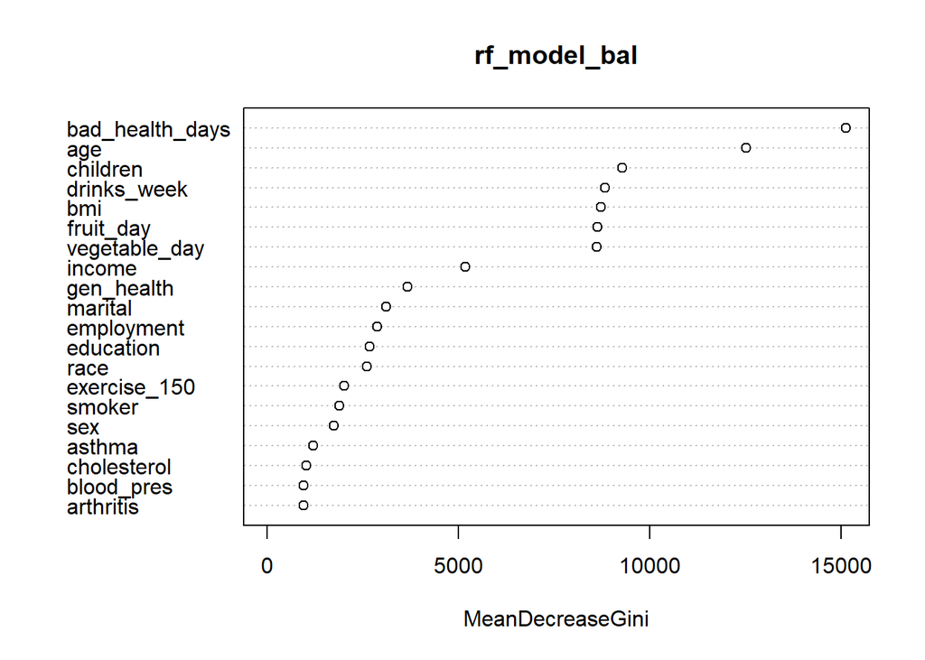

```r
#Random Forest
varImpPlot(rf_model_bal)
```

```r
#Naive Bayes
varImp(train_NB_kf)
```

```
## ROC curve variable importance
##
##                 Importance
## age                100.000
## gen_health          81.529
## bad_health_days     80.367
## sex                 49.308
## income              43.204
## exercise_150        30.074
## children            28.689
## asthma              28.461
## smoker              25.657
## fruit_day           22.478
## arthritis           18.928
## vegetable_day       13.660
## marital             11.531
## bmi                 11.460
## employment           9.312
## blood_pres           7.466
## race                 3.402
## education            3.371
## drinks_week          2.093
## cholesterol          0.000
```

```r
#Logistic Regression
varImp(train_log_kf)
```

```
## glm variable importance
##
##   only 20 most important variables shown (out of 45)
##
##                                Overall
## age                             100.00
## sexMale                          79.85
## gen_healthExcellent              53.76
## bad_health_days                  52.84
## `gen_healthVery Good`            36.09
## arthritisYes                     29.77
## gen_healthGood                   25.92
## `educationPost Secondary`        23.28
## `employmentUnable to Work`       23.04
## employmentRetired                22.42
## maritalMarried                   21.24
## asthmaNever                      20.88
## `smokerNever Smoked`             20.80
## drinks_week                      19.95
## cholesterolYes                   19.94
## `educationSome Post Secondary`   15.90
## raceWhite                        15.11
## raceMultiracial                  14.07
## `smokerFormer Smoker`            12.47
## `exercise_1501-149`              11.95
```

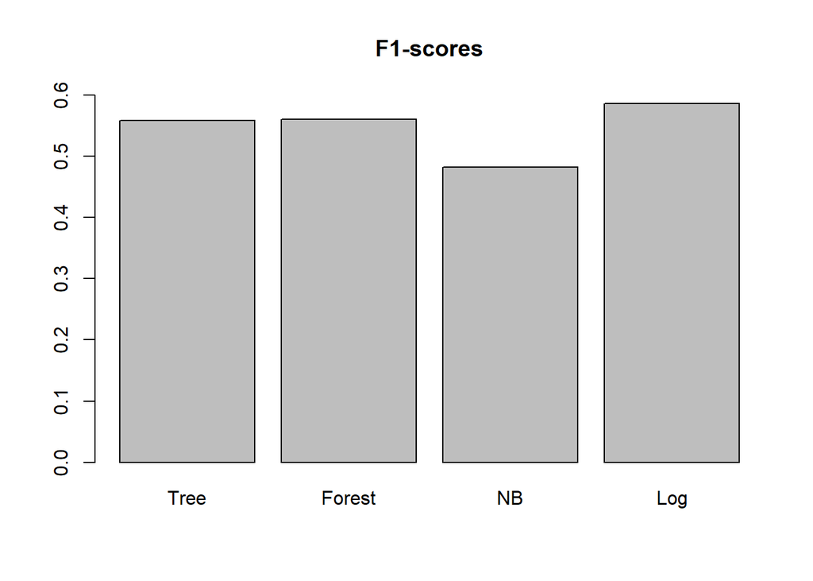

```r
model_names <- c("Tree", "Forest", "NB", "Log")
F1_height <- c(tree_cm_kf$byClass[7], forest_cm_bal$byClass[7],
               NB_cm_kf$byClass[7], log_cm_kf$byClass[7])
barplot(height = F1_height, names = model_names, main = "F1-scores",
        ylim = c(0,0.6))
```

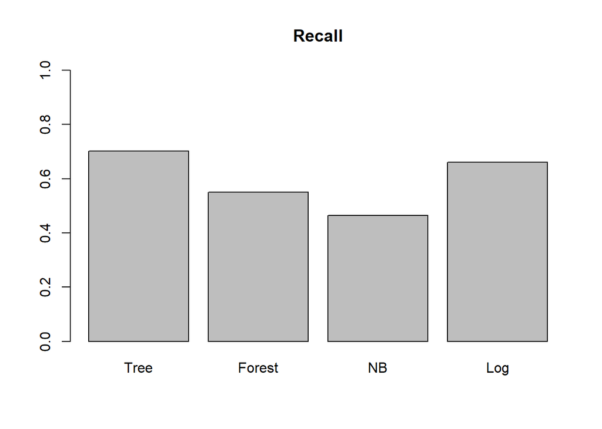

```r
recall_height <- c(tree_cm_kf$byClass[6], forest_cm_bal$byClass[6],
                   NB_cm_kf$byClass[6], log_cm_kf$byClass[6])
barplot(height = recall_height, names = model_names, main = "Recall",
        ylim = c(0,1))
```